# Meeting 5 - In Class Notes

Matt

2/26/2020

# Probability through M&Ms

```r
mm_counts <- c(57, 55, 56, 55, 55, 43, 54, 56, 50)
```

On average, how many m&ms will I get in a bag

```r
sum(mm_counts) / length(mm_counts)
```

```
## [1] 53.44444
```

Sample mean

$$\bar{x} = \frac{\sum_{i=1}^n{x_i}}{n}$$
There is also a population mean, denoted by $\mu$.

```r
mean(mm_counts)
```

```
## [1] 53.44444
```

## Quantify variation in the number of M&Ms we might expect to get in a bag

- Standard deviation - will return to this shortly
- total distance of my observed m&m counts from the mean count

```r
mm_counts
```

```
## [1] 57 55 56 55 55 43 54 56 50
```

```r
dist_from_mean <- mm_counts - mean(mm_counts)
dist_from_mean
```

```
## [1]   3.5555556   1.5555556   2.5555556   1.5555556   1.5555556 -10.4444444
## [7]   0.5555556   2.5555556  -3.4444444
```

Get a single number to discuss variability

```r
sum(dist_from_mean)
```

```
## [1] 1.421085e-14
```

- Sum of absolute values

```r
sum(abs(dist_from_mean))
```

```
## [1] 27.77778
```

- sum of squared values

```r
sum(dist_from_mean^2)
```

```
## [1] 154.2222
```

Also called squared deviations from the mean

Advantage of squared vs absolute - squared yields a continuous function, where as absolute has a point of discontinuity.

- variance

sum of squared distances / n-1

$$var = \frac{\sum_{i=1}^n{(\bar{x} - x_i)^2}}{n-1}$$

Intuitively think of this as - is the average squared distance of any observation

Take the square root of var, and you get the average absolute distance from the mean of any observation

standard deviation = square root of variance

#### Challenge

1. calculate the variance of the number of M&Ms in a bag, using basic functions - `sum` `/` `length` Check your answer against `var`
2. Do the same for standard deviation.

```r
sum( (mean(mm_counts) - mm_counts)^2 ) / (length(mm_counts) - 1)
```

```
## [1] 19.27778
```

```r
var(mm_counts)
```

```
## [1] 19.27778
```

### do this all for SD

```r
sqrt(sum( (mean(mm_counts) - mm_counts)^2 ) / (length(mm_counts) - 1))
```

```
## [1] 4.390647
```

```r
sd(mm_counts)
```

```
## [1] 4.390647
```

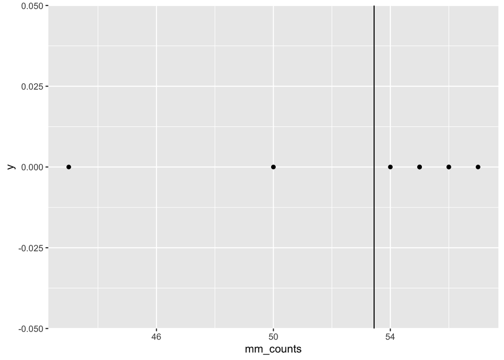

```r
library(ggplot2)

ggplot() +
  geom_point(aes(x = mm_counts, y = 0)) +
  geom_vline(xintercept = mean(mm_counts))
```

# Probability

Choose an m&m

You could have chosen a:

{brown, blue, yellow, orange, red, green} a set, our sample space

sample space = is the set that includes all possible outcomes of an event

Event = the selection of one m&m

```r
runif(1)
```

```
## [1] 0.01979775
```

Assuming all color m&ms are equally likely, what’s the probability that your event is a green m&m?

1/6

Let’s get our data set

```r
mm_data <- read.csv(file = "mm_data.csv")
mm_data
```

```
##    Color Matt Brendan Felix Ralph Zach Nupur Teresa Xiping Shifan
## 1   blue    8       3     7    13    7     7      6      4      7
## 2  brown    6       6     5     4    3     6      5      6      6
## 3  green    9      12     9    14    8     6     11      9      7
## 4 orange   19      26    17    12   25     7     22     16     14
## 5    red   10       3     6     4    3     7      6      6      7
## 6 yellow    5       5    11     9   10    10      5     13      9
```

#### A brief intro into tidyverse

```r
install.packages("tidyverse")
```

```r
library(tidyverse)
mm_data
```

```
##    Color Matt Brendan Felix Ralph Zach Nupur Teresa Xiping Shifan
## 1   blue    8       3     7    13    7     7      6      4      7
## 2  brown    6       6     5     4    3     6      5      6      6
## 3  green    9      12     9    14    8     6     11      9      7
## 4 orange   19      26    17    12   25     7     22     16     14
## 5    red   10       3     6     4    3     7      6      6      7
## 6 yellow    5       5    11     9   10    10      5     13      9
```

Transform our data into long-format

```r
mm_data_long <- tidyr::gather(mm_data, "Person", "MM_Count", 2:10)
mm_data_long
```

```
##     Color  Person MM_Count
## 1    blue    Matt        8
## 2   brown    Matt        6
## 3   green    Matt        9
## 4  orange    Matt       19
## 5     red    Matt       10
## 6  yellow    Matt        5
## 7    blue Brendan        3
## 8   brown Brendan        6
## 9   green Brendan       12
## 10 orange Brendan       26
## 11    red Brendan        3
## 12 yellow Brendan        5
## 13   blue   Felix        7
## 14  brown   Felix        5
```

[output cut: 40 more lines]

**Calc total M&Ms in each bag**

```r
mm_data_long %>%
  group_by(Person) %>%
  summarise(Tot_MM = sum(MM_Count))
```

```
## # A tibble: 9 x 2
##   Person  Tot_MM
##   <chr>    <int>
## 1 Brendan     55
## 2 Felix       55
## 3 Matt        57
## 4 Nupur       43
## 5 Ralph       56
## 6 Shifan      50
## 7 Teresa      55
## 8 Xiping      54
## 9 Zach        56
```

**Add a new column to mm_data_long with the total MM counts**

```r
mm_data_long <-
  mm_data_long %>%
  group_by(Person) %>%
  mutate(Tot_MM = sum(MM_Count))

mm_data_long
```

```
## # A tibble: 54 x 4
## # Groups:   Person [9]
##    Color  Person  MM_Count Tot_MM
##    <fct>  <chr>      <int>  <int>
##  1 blue   Matt           8     57
##  2 brown  Matt           6     57
##  3 green  Matt           9     57
##  4 orange Matt          19     57
##  5 red    Matt          10     57
##  6 yellow Matt           5     57
##  7 blue   Brendan        3     55
##  8 brown  Brendan        6     55
##  9 green  Brendan       12     55
## 10 orange Brendan       26     55
## # … with 44 more rows
```

**Calc probability of getting any particular color for each person**

```r
mm_data_long$Prob_Color <- mm_data_long$MM_Count / mm_data_long$Tot_MM
mm_data_long
```

```
## # A tibble: 54 x 5
## # Groups:   Person [9]
##    Color  Person  MM_Count Tot_MM Prob_Color
##    <fct>  <chr>      <int>  <int>      <dbl>
##  1 blue   Matt           8     57     0.140
##  2 brown  Matt           6     57     0.105
##  3 green  Matt           9     57     0.158
##  4 orange Matt          19     57     0.333
##  5 red    Matt          10     57     0.175
##  6 yellow Matt           5     57     0.0877
##  7 blue   Brendan        3     55     0.0545
##  8 brown  Brendan        6     55     0.109
##  9 green  Brendan       12     55     0.218
## 10 orange Brendan       26     55     0.473
## # … with 44 more rows
```

#### Challenge

What is the man probablity of getting each color across the bags?

```r
mm_data_long %>%
  group_by(Color) %>%
  summarise(Prob_Color = mean(Prob_Color))
```

```
## # A tibble: 6 x 2
##   Color  Prob_Color
##   <fct>       <dbl>
## 1 blue       0.129
## 2 brown      0.0991
## 3 green      0.175
## 4 orange     0.324
## 5 red        0.110
## 6 yellow     0.162
```

## Probability of events

whats the prob(green OR blue OR red)?

= prob(green) + prob(blue) + prob(red)

what’s the prob of not green?

= 1 - p(green) = p(blue) + prob(red) + prob( brown) + p(yellow) + p(orange)

$$P(\sim Green) = P(Not Green) = P(Green)^c$$

### Sampling with replacement

I draw one M&M from my bag, put it back, then draw another

- What’s the P(green and then blue)?

P(green) * P(blue)

### Samlping without replacement

I draw one M&M, eat it, then draw another

- What’s the P(Green and then blue)?

#### Challenge

What is the sample space when drawing two M&Ms?

```r
mm_colors <- c("blue", "brown", "green", "orange", "red", "yellow")
mm_probs <- c(0.23, 0.14, 0.16, 0.2, 0.13, 0.14)
```

Let’s “sample” a new bag

```r
new_bag <- sample(x = mm_colors, size = 57, replace = TRUE, prob = mm_probs)
new_bag
```

```
##  [1] "yellow" "orange" "orange" "orange" "green"  "blue"   "blue"   "green"
##  [9] "green"  "blue"   "blue"   "brown"  "orange" "green"  "blue"   "orange"
## [17] "blue"   "brown"  "orange" "blue"   "blue"   "blue"   "red"    "red"
## [25] "blue"   "blue"   "brown"  "orange" "blue"   "yellow" "orange" "red"
## [33] "green"  "brown"  "blue"   "red"    "brown"  "green"  "green"  "brown"
## [41] "red"    "brown"  "red"    "orange" "blue"   "blue"   "orange" "green"
## [49] "brown"  "red"    "blue"   "green"  "brown"  "green"  "green"  "red"
## [57] "blue"
```

```r
table(new_bag)
```

```
## new_bag
##   blue  brown  green orange    red yellow
##     17      9     11     10      8      2
```

Get new bag color counts

```r
new_bag_counts <- c(sum(new_bag == "blue"),
                    sum(new_bag == "brown"),
                    sum(new_bag == "green"),
                    sum(new_bag == "orange"),
                    sum(new_bag == "red"),
                    sum(new_bag == "yellow")
                    )
new_bag_counts
```

```
## [1] 17  9 11 10  8  2
```

```r
mm_matts <- mm_data$Matt
mm_matts
```

```
## [1]  8  6  9 19 10  5
```

```r
sum(mm_matts)
```

```
## [1] 57
```

Does my bag match the simulated bag?

```r
all(mm_matts == new_bag_counts)
```

```
## [1] FALSE
```

Another, side, example of sample

Shuffle numbers / permute numbers

```r
sample(1:10, replace = FALSE)
```

```
##  [1]  9 10  7  4  8  2  6  5  3  1
```

Sample w replacement (boot strap)

```r
sample(1:10, replace = TRUE)
```

```
##  [1] 5 3 2 7 5 5 6 8 7 9
```